# Lab 3: Randomization Testing and Recidivism Risk

Erica Chen

8 May 2020

Exercise 1: Race and Score Number

```r
compareMeans(score_num,race)
```

```
## Difference in means:  1.64
```

```
##               race score_num
## 1 African-American  5.276850
## 2        Caucasian  3.635283
```

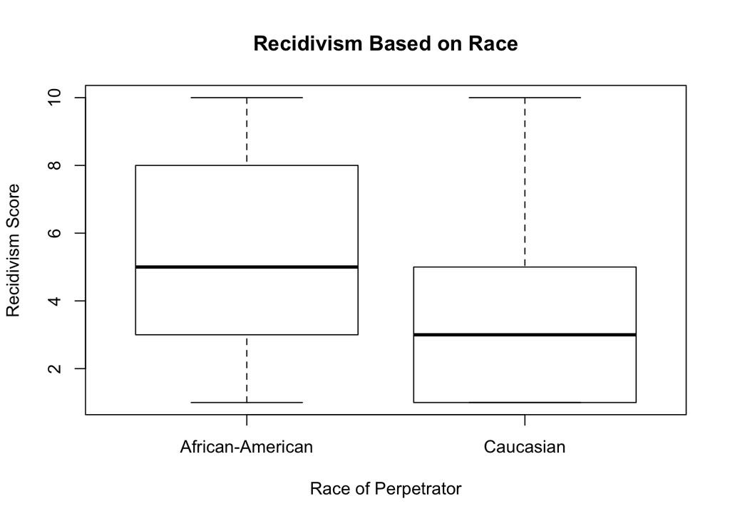

```r
boxplot(score_num~race, xlab= "Race of Perpetrator" , ylab= "Recidivism Score" , main= "Recidivism Based on Race")
```

According to side by side box and whisker plot above, African-American has an average recidivism score of 5.28 and Caucasian has a score of 3.64 with a difference of 1.64. Though populations have perpetrators at the minimum and maximum points, the African American population is more concentrated around higher recidivism scores.

```r
set.seed(1010)
randomization.test(score_num,race,num=10000)
```

```
## Variable 1: quantitative , Variable 2: categorical
## Observed Difference in Means: 1.642
## Randomizing, please wait...
```

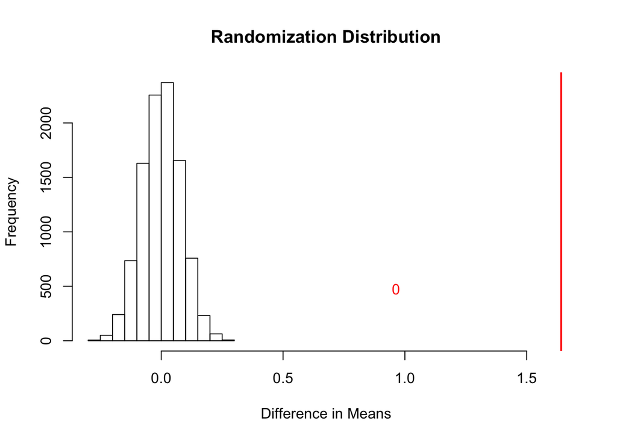

```
## SE =  0.08
## Smaller Tail Probability:  0
```

To test the null hypothesis, we ran 10,000 random simulations and calculated the p-value to be 0% - a probability significant enough to be able to reject the null hypothesis and favor the alternative, which is H1: μ_A /= μ_C. We can conclude that there is, in fact, an association between race and recidivism score.

Exercise 2: Race and Severity of the Crime

```r
compareProportions(degree,race)
```

```
## Difference in proportions:  0.1
```

```
##               race degree.Felony degree.Misdemeanor
## 1 African-American     0.6916535          0.3083465
## 2        Caucasian     0.5915359          0.4084641
```

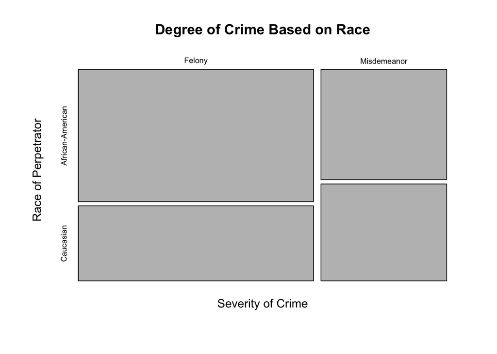

```r
plot(table(degree,race), ylab= "Race of Perpetrator" , xlab= "Severity of Crime", main= "Degree of Crime Based on Race" )
```

The two way table above compares two proportions, with the observed difference in proportion to be 0.1. The null hypothesis tests that the proportions are equal, H0: P_a = P_c. We can observe that African American committing felonies is the greatest population recorded followed by Caucaians committing felonies.

```r
set.seed (2020)
randomization.test(degree, race, num=10000)
```

```
## Variable 1: categorical , Variable 2: categorical
## Observed Difference in Proportions: 0.1
## Randomizing, please wait...
```

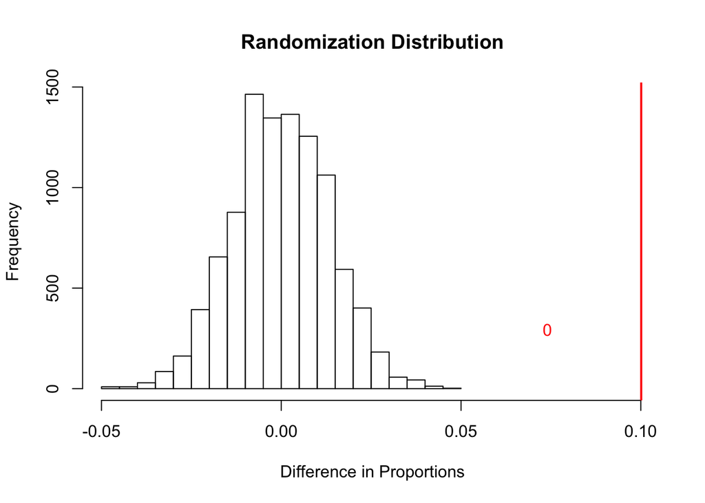

```
## SE =  0.013
## Smaller Tail Probability:  0
```

According to the histogram above, the p-value calculated after 10,000 random samples shows a probability of 0%. The null hypothesis is rejected. Therefore, we favor the alternative hypothesis showing that there is an association between race and degree of crime. The histogram displays a bell shaped distribution with an almost slanted unimodal peak.

Exercise 3a: Sex and COMPAS Score

```r
compareMeans(score_num, sex)
```

```
## Difference in means:  -0.47
```

```
##      sex score_num
## 1 Female  4.243453
## 2   Male  4.714858
```

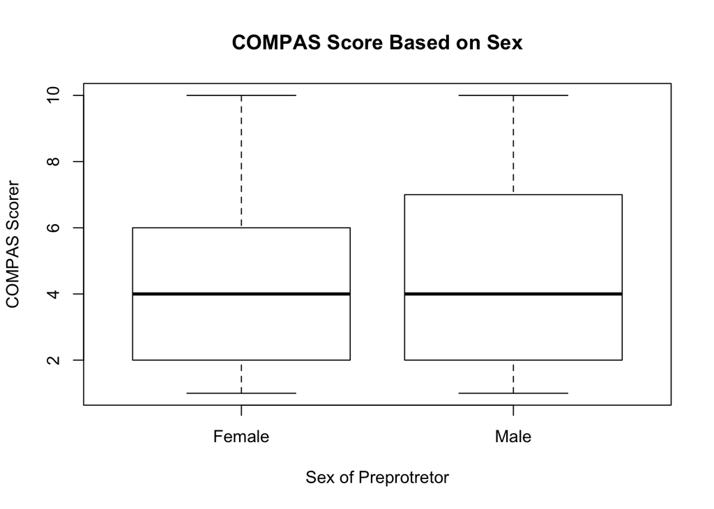

```r
boxplot(score_num~sex, ylab= "COMPAS Scorer" , xlab= "Sex of Preprotretor" , main= "COMPAS Score Based on Sex")
```

```r
set.seed (3030)
randomization.test(score_num, sex, num=10000)
```

```
## Variable 1: quantitative , Variable 2: categorical
## Observed Difference in Means: -0.471
## Randomizing, please wait...
```

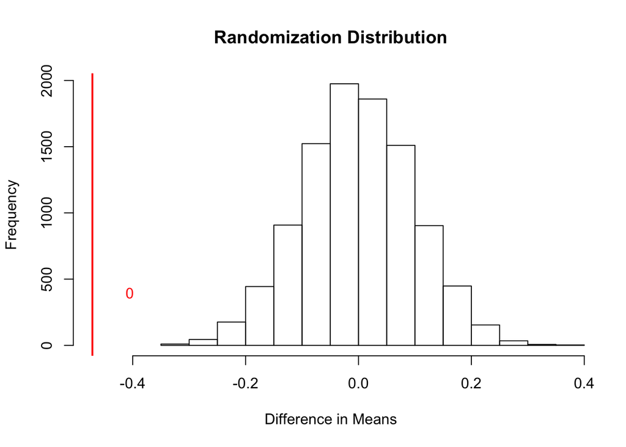

```
## SE =  0.099
## Smaller Tail Probability:  0
```

To test the null hypothesis, we ran 10,000 random samples and calculated a p-value of 0%- a probability significant enough to reject the null hypothesis to favor the alternative. We can conclude that there is an association between sex and COMPAS score.

Exercise 3b: Subset with No Prior Convictions

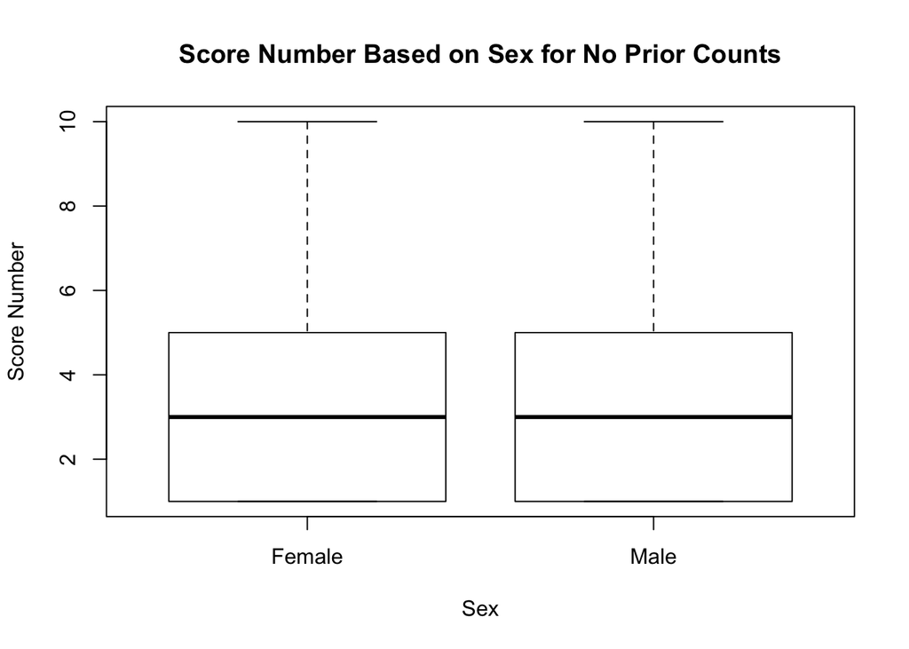

```r
no.prior <-subset (spring_2020_lab_3_data, priors_count==0)

plot(no.prior$score_num~no.prior$sex, main= "Score Number Based on Sex for No Prior Counts", xlab= "Sex", ylab="Score Number")
```

```r
set.seed(30311)
randomization.test(no.prior$score_num, no.prior$sex, num=10000)
```

```
## Variable 1: quantitative , Variable 2: categorical
## Observed Difference in Means: -0.022
## Randomizing, please wait...
```

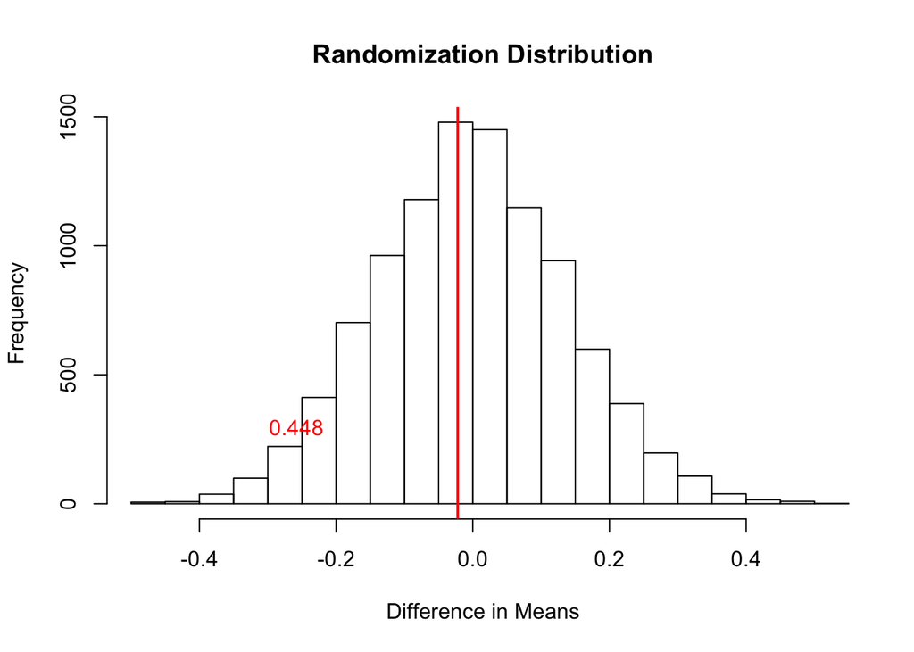

```
## SE =  0.14
## Smaller Tail Probability:  0.4479
```

Exercise 3c: Summary

The difference in mean displayed in preliminary calculations can describe how far apart the means are from each other. So the smaller the difference, the closer the means are to being equal and supporting the null hypothesis. We can conclude that 0.44 is not a statistically significant number, so we reject the alternative hypothesis because the means are not too different to be considered significant.

Exercise 4a: Hypothesis Testing Two Means

```r
compareMeans(priors_count,degree)
```

```
## Difference in means:  1.37
```

```
##        degree priors_count
## 1      Felony     3.938953
## 2 Misdemeanor     2.568009
```

My research question is to determine if there is a difference between felony based on prior counts and between misdemeanor based on prior counts.

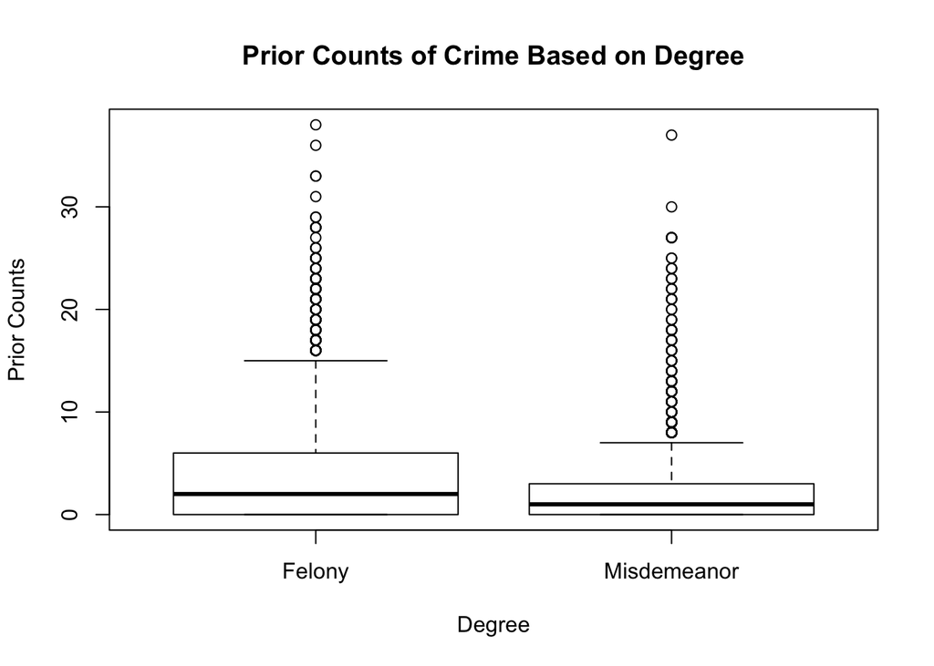

```r
boxplot(priors_count~degree, main= "Prior Counts of Crime Based on Degree" , xlab= "Degree" , ylab= "Prior Counts" )
```

```r
set.seed(100)

randomization.test(priors_count, degree, num=10000)
```

```
## Variable 1: quantitative , Variable 2: categorical
## Observed Difference in Means: 1.371
## Randomizing, please wait...
```

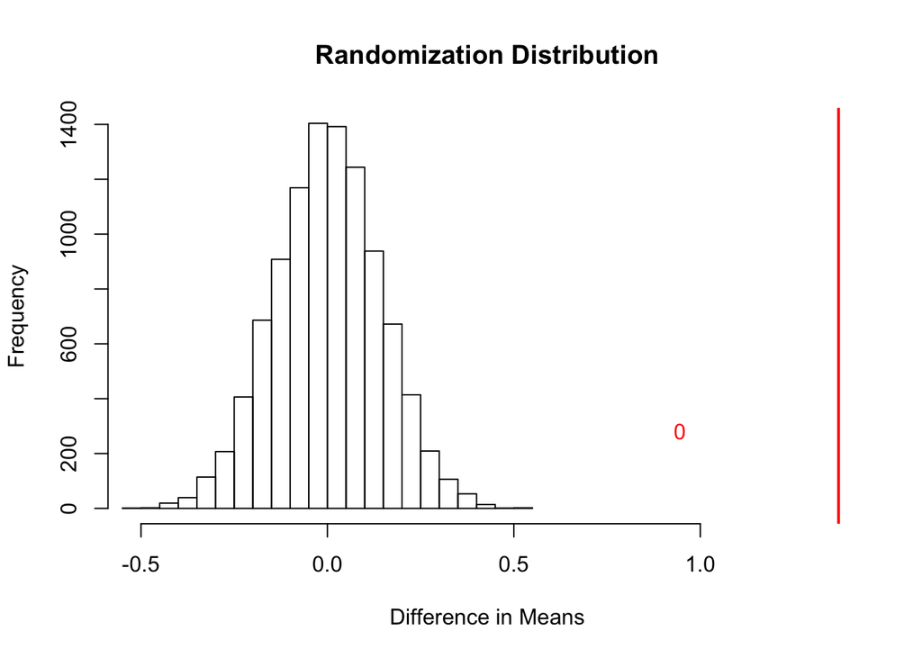

```
## SE =  0.142
## Smaller Tail Probability:  0
```

After analyzing the histogram, we can conclude that the smaller tail (to the right) has a probability of zero, making the p-value statistically significant and rejecting the null hypothesis to claim that there is an association between degree of the crime and prior counts committed by the perpetrator.

Exercise 4b: Hypothesis Testing Subsets

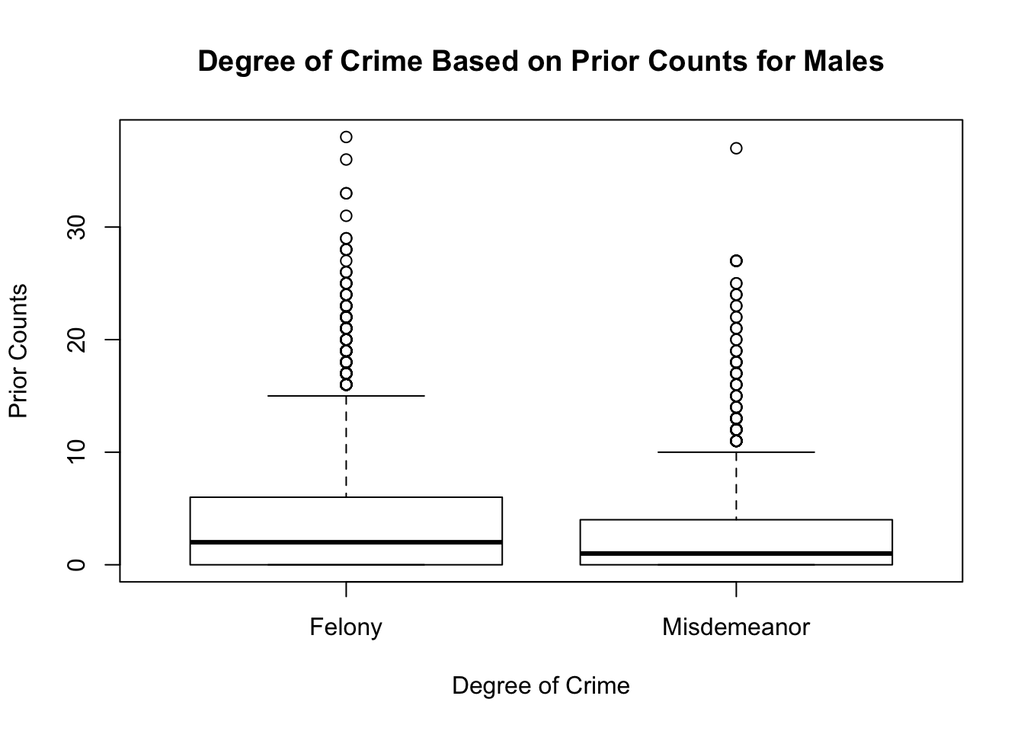

```r
male <-subset(spring_2020_lab_3_data, sex== "Male")

plot(male$priors_count~male$degree, main= "Degree of Crime Based on Prior Counts for Males", ylab= "Prior Counts", xlab= "Degree of Crime")
```

```r
set.seed(4040)
randomization.test(male$priors_count, male$degree, num=10000)
```

```
## Variable 1: quantitative , Variable 2: categorical
## Observed Difference in Means: 1.261
## Randomizing, please wait...
```

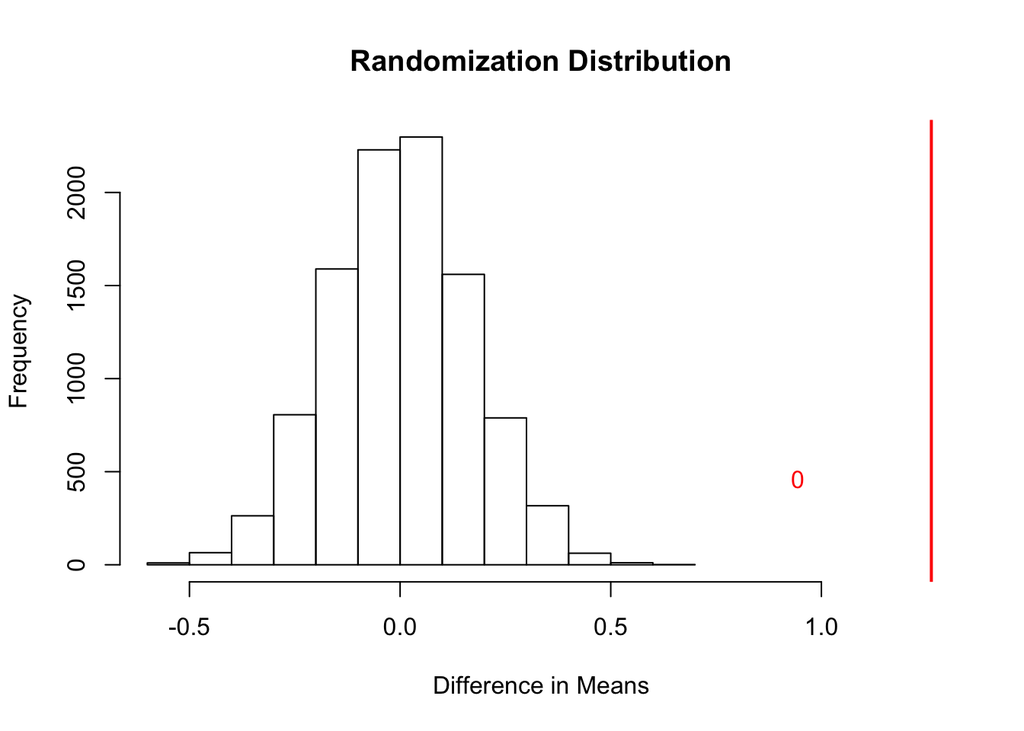

```
## SE =  0.167
## Smaller Tail Probability:  0
```

After simulating 10,000 random samples specific to the male population, we can conclude that the data is statistically significant therefore rejecting the null hypothesis again. The histogram above represents a neatly centered normal distribution.

Exercise 5: Summary

My intention is to measure the association between two means using the variables “Degree” and “Prior Counts.” I found it interesting that perpetrators who committed felonies had a greater number of counts for commiting prior crimes. The data also shows a wider range of perpetrators committing felonies than misdemeanor, where the number of perpetrators hat committed misdemeanor had similar criminal history (fewer prior counts).

I am curious to test if there is an association between degree of crime and prior counts of crime between various countries around the world based of system of governing: democratic countries versus communist countries. For a previous lab report, we observed the happy life years between countries around the world, and I was surprised to find many communists countries were higher up on the HLY scale, even higher than the U.S. I would hypothesize that there is an association between these two variables: if more citizens live a happier lifestyle this could impact the recorded crime activity.